# Midterm

Data Visualization (STAT 302)

Author

Dave Arthur

Published

November 3, 2024

## Overview

The midterm attempts to bring together everything you have learned to date. You’ll be asked to replicate a series of graphics to demonstrate your skills and provide short descriptions/explanations regarding issues and concepts in `ggplot2`.

You are free to use any resource at your disposal such as notes, past labs, the internet, fellow students, instructor, TA, etc. However, do not simply copy and paste solutions. This is a chance for you to assess how much you have learned and determine if you are developing practical data visualization skills and knowledge.

## Datasets

The datasets used for this dataset are `stephen_curry_shotdata_2023_24.txt`, `ga_election_data.csv`, and `ga_map.rda`. We will also need the `nbahalfcourt.jpg` image.

Below you can find a short description of the variables contained in `stephen_curry_shotdata_2023_24.txt`:

- `GAME_ID` - Unique ID for each game during the season
- `HOME` - Indicates if game is `"Home"` or `"Away"`
- `PLAYER_ID` - Unique player ID
- `PLAYER_NAME` - Player’s name
- `TEAM_ID` - Unique team ID
- `TEAM_NAME` - Team name
- `PERIOD` - Quarter or period of the game
- `MINUTES_REMAINING` - Minutes remaining in quarter/period
- `SECONDS_REMAINING` - Seconds remaining in quarter/period
- `EVENT_TYPE` - `Missed Shot` or `Made Shot`
- `SHOT_DISTANCE` - Shot distance in feet
- `LOC_X` - X location of shot attempt according to tracking system
- `LOC_Y` - Y location of shot attempt according to tracking system

The `ga_election_data.csv` dataset contains the state of Georgia’s county level results for the 2020 US presidential election. Here is a short description of the variables it contains:

- `County` - name of county in Georgia
- `Candidate` - name of candidate on the ballot,
- `Election Day Votes` - number of votes cast on election day for a candidate within a county
- `Absentee by Mail Votes` - number of votes cast absentee by mail, pre-election day, for a candidate within a county
- `Advanced Voting Votes` - number of votes cast in-person, pre-election day, for a candidate within a county
- `Provisional Votes` - number of votes cast on election day for a candidate within a county needing voter eligibility verification
- `Total Votes` - total number of votes for a candidate within a county

We have also included the map data for Georgia (`ga_map.rda`) which was retrieved using `tigris::counties()`.

```r
# load package(s)
library(tidyverse)
library(ggthemes)
library(patchwork)
library(janitor)
library(cowplot)
library(showtext)
library(dplyr)
library(rlang)
library(sf)
library(ggrepel)

# load steph curry data
steph_data <- read_delim(file = "data/stephen_curry_shotdata_2023_24.txt", delim = "|")

# load ga election & map data
load("data/ga_map.rda")
ga_election_dat <- read_csv("data/ga_election_data.csv")
```

## Exercise 1

Using the `stephen_curry_shotdata_2023_24.txt` dataset replicate, as close as possible, the graphics below. After replicating the graphics provide a summary of what the graphics indicate about Stephen Curry’s shot selection such as distance from hoop, shot make/miss rate, how do makes and misses compare across distance and game time (i.e. across quarters/periods).

### Plot 1

*Hints:*

- Figure width 6 inches and height 4 inches, which is taken care of in code chunk yaml with `fig-width` and `fig-height`
- Use `minimal` theme and adjust from there
- Useful hex colors: `"#1D428A"` and `"#FFC72C80"`
- While the plot needs to be **very close** to the one shown it does not need to be **exact** in terms of values. If you want to make it exact here are some useful values used, sometimes repeatedly, to make the plot: 12, 14, & 16

**Solution**

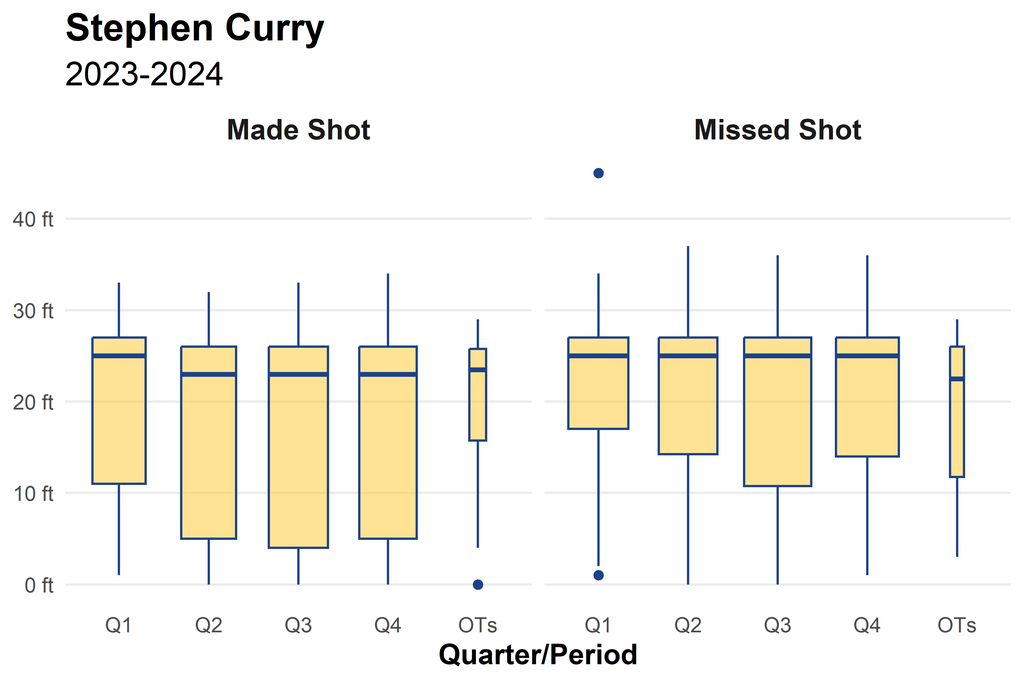

```r
# data prep
steph_data <- steph_data |>
  mutate(
    PERIOD = if_else(PERIOD > 5, 5, PERIOD),
    PERIOD = factor(
      PERIOD,
      levels = c(1, 2, 3, 4, 5),
      labels = c("Q1", "Q2", "Q3", "Q4", "OTs")
    )
  ) |>
  filter(SHOT_DISTANCE < 47)

# Create the shot plot
ggplot(steph_data, aes(PERIOD, SHOT_DISTANCE)) +
  geom_boxplot(varwidth = TRUE, fill = "#FFC72C80", color = "#1D428A") + # Adjust colors of box plot
  theme_minimal() +
  facet_wrap(~EVENT_TYPE, nrow = 1) + # Create two diff plots based on made/missed shot
  # Add and adjust labels
  labs(x = "Quarter/Period", y = NULL) +
  ggtitle("Stephen Curry", subtitle = "2023-2024") +
  theme(axis.title.x = element_text(face="bold", size = 12)) +
  theme(plot.title = element_text(face = "bold", size = 16)) +
  theme(plot.subtitle = element_text(size = 14)) +
  theme(strip.text.x = element_text(face = "bold", size = 12)) +
  # Change scaling of y axis
  scale_y_continuous(breaks = seq(0, 40, 10),
                     labels = scales::label_number(suffix = " ft")) +
  # Get rid of unnecessary grid lines
  theme(panel.grid.minor = element_blank()) +
  theme(panel.grid.major.x = element_blank())
```

### Plot 2

*Hints:*

- Figure width 6 inches and height 4 inches, which is taken care of in code chunk yaml with `fig-width` and `fig-height`
- Use `minimal` theme and adjust from there
- Useful hex colors: `"#5D3A9B"` and `"#E66100"`
- No padding on vertical axis
- Transparency is being used
- `annotate()` is used to add labels
- While the plot needs to be **very close** to the one shown it does not need to be **exact** in terms of values. If you want to make it exact here are some useful values used, sometimes repeatedly, to make the plot: 0, 0.035, 0.081, 0.09, 0.25, 4.5, 12, 14, 16, 27.5

**Solution**

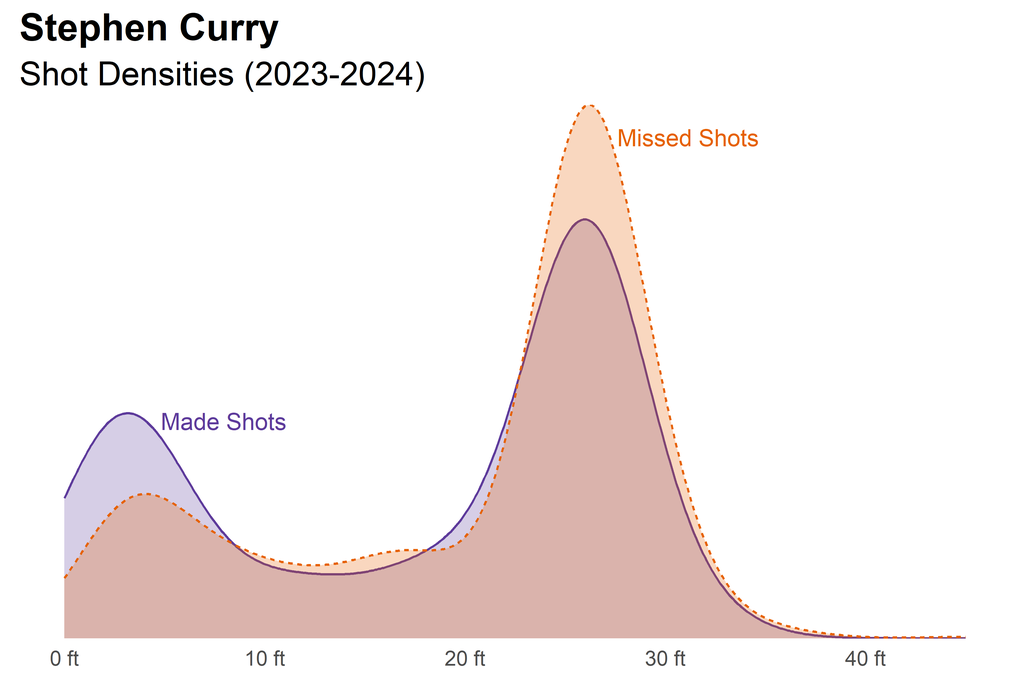

```r
# Create the density plot
ggplot(steph_data, aes(x = SHOT_DISTANCE)) +
  geom_density(aes(color = EVENT_TYPE, fill = EVENT_TYPE, lty = EVENT_TYPE),
               alpha = 0.25,
               show.legend = FALSE) +
  theme_minimal() +
  labs(x = NULL, y = NULL) + # Get rid of axis labels
  # Add and adjust title/subtitle
  ggtitle("Stephen Curry", subtitle = "Shot Densities (2023-2024)") +
  theme(plot.title = element_text(face = "bold", size = 16)) +
  theme(plot.subtitle = element_text(size = 14)) +
  # Adjust scaling of x axis
  scale_x_continuous(breaks = seq(0, 40, 10),
                     labels = scales::label_number(suffix = " ft")) +
  # Get rid of extra space under x-axis
  scale_y_continuous(labels = NULL, expand = c(0, 0)) +
  # Get rid of unnecessary grid lines
  theme(panel.grid.minor = element_blank()) +
  theme(panel.grid.major = element_blank()) +
  # Adjust colors/borders used
  scale_fill_manual(values = c("#5D3A9B", "#E66100")) +
  scale_color_manual(values = c("#5D3A9B", "#E66100")) +
  scale_linetype_manual(values = c("solid", 22)) +
  # Add labels for made/missed shots
  annotate("text",
          x = 4.5, y = 0.035,
          label = "Made Shots",
          hjust = -0.05, vjust = 0.25,
          color = "#5D3A9B",
          size = 3.5) +
  annotate("text",
          x = 27.5, y = 0.081,
          label = "Missed Shots",
          hjust = -0.015, vjust = 0,
          color = "#E66100",
          size = 3.5)
```

### Plot 3

*Hints:*

- Figure width 7 inches and height 7 inches, which is taken care of in code chunk yaml with `fig-width` and `fig-height`
- Colors used: `"grey"`, `"red"`, `"orange"` `"yellow"` (don’t have to use `"orange"`, you can get away with using only `"red"` and `"yellow"`)
- To set `15+` as the highest value, you need to set the limits in the appropriate scale while also setting the `na.value` to the top color
- While the plot needs to be **very close** to the one shown it does not need to be **exact** in terms of values. If you want to make it exact here are some useful values used, sometimes repeatedly, to make the plot: 0, 0.7, 5, 12, 14, 15, 16, 20

**Solution**

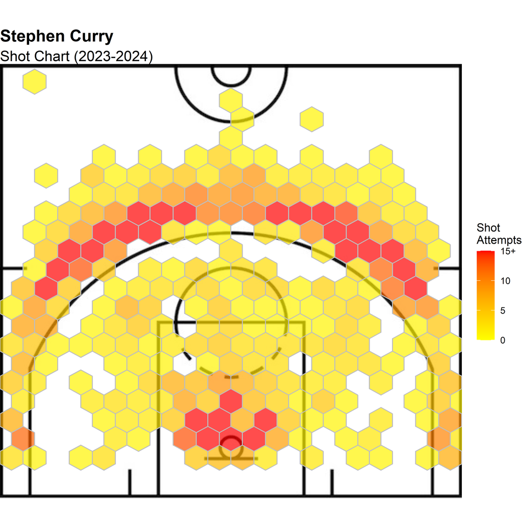

```r
# importing image of NBA half court
court <- grid::rasterGrob(
  jpeg::readJPEG(
    source = "data/nbahalfcourt.jpg"),
  width = unit(1, "npc"),
  height = unit(1, "npc")
)

# plot
ggplot(steph_data, aes(x = LOC_X, y = LOC_Y)) +
  annotation_custom(
    grob = court,
    xmin = -25, xmax = 25,
    ymin = 0, ymax = 47
  ) +
  coord_fixed(expand = FALSE) +
  xlim(-25, 25) +
  ylim(0, 47) +
  # Create the hex bin plot
  stat_binhex(color = "gray", bins = 20, alpha = 0.7) +
  # Add the color gradient
  scale_fill_gradientn("Shot\nAttempts",
                       colors = c("yellow", "orange", "red"),
                       na.value = "red",
                       breaks = c(0, 5, 10, 15),
                       limits = c(0, 15),
                       labels = c("0", "5", "10", "15+")) + # Change the scale on the right
  labs(x = NULL, y = NULL, color = NULL) + # Get rid of unneeded labels
  # Add and adjust the title/subtitle
  ggtitle("Stephen Curry", subtitle = "Shot Chart (2023-2024)") +
  theme_void() +
  theme(plot.title = element_text(face = "bold", size = 16)) +
  theme(plot.subtitle = element_text(size = 14)) +
  # Add extra space between edge of court image and legend
  theme(legend.box.spacing = unit(0.2, "in"))
```

### Summary

Provide a summary of what the graphics above indicate about Stephen Curry’s shot selection such as distance from hoop, shot make/miss rate, how do makes and misses compare across distance and game time (i.e. across quarters/periods).

## Exercise 2

Using the `ga_election_data.csv` dataset in conjunction with mapping data `ga_map.rda` replicate, as close as possible, the graphic below. Note the graphic is comprised of two plots displayed side-by-side. The plots both use the same shading scheme (i.e. scale limits and fill options).

**Background Information**

Holding the 2020 US Presidential election during the COVID-19 pandemic was a massive logistical undertaking. Additional voter engagement was extremely historically high. Voting operations, headed by states, ran very smoothly and encountered few COVID-19 related issues. The state of Georgia did a particularly good job at this by encouraging their residents to use early voting. About 75% of the vote in a typical county voted early! Statewide, about 80% or 4 in every 5 voters in Georgia voted early.

While it is clear that early voting was the preferred option for Georgia voters, we want to investigate whether or not voters for one candidate/party utilized early voting more than the other — we are focusing on the two major candidates/parties. We created the graphic below to explore the relationship of voting modality and voter preference, which you are tasked with recreating.

*Hints:*

- Figure width 7 inches and height 7 inches, which is taken care of in code chunk yaml with `fig-width` and `fig-height`
- Make two plots, then arrange plots accordingly using `patchwork` package
- `patchwork::plot_annotation()` will be useful for adding graphic title and caption; you’ll also set the theme options for the graphic title and caption (think font size and face) — **code has been provided**
- `ggthemes::theme_map()` was used as the base theme for the plots
- `scale_*_gradient2()` will be helpful
- Useful hex colors: `"#5D3A9B"` and `"#1AFF1A"`
- While the plot needs to be **very close** to the one shown it does not need to be **exact** in terms of values. If you want to make it exact here are some useful values used, sometimes repeatedly, to make the plot: 0.5, 0.75, 1, 10, 12, 14, 24

### Plot

**Solution**

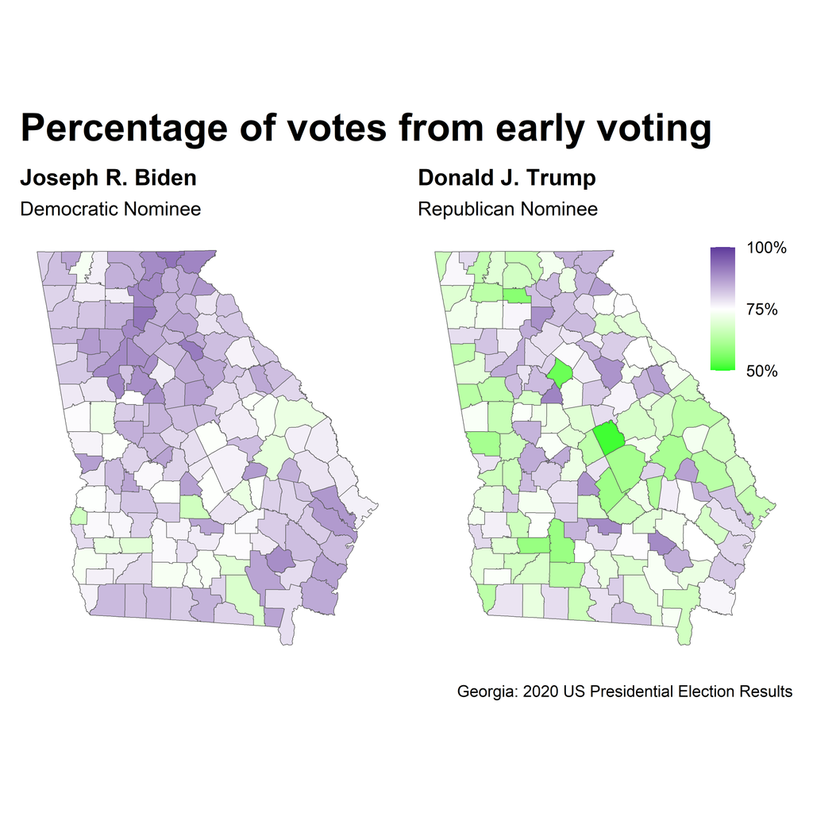

```r
# data
  # Changed variable names manually to eliminate spaces
ga_graph <- ga_election_dat |>
  # Add a new variable that determines the percentage of votes completed by mail-in
  mutate(
    prop_pre_eday = (Absentee_by_Mail_Votes + Advanced_Voting_Votes) / Total_Votes
  ) |>
  # Get rid of the columns with _vote in the name of the column
  select(-contains("_vote"))

# Biden map data
biden_map_data <- ga_map |>
  # Keep all rows where the candidate voted for was Joe Biden
  left_join(
    ga_graph |>
      filter(Candidate == "Joseph R. Biden"),
    by = c(name = "County")
  )

# trump map data
trump_map_data <- ga_map |>
  # Keep all rows where the candidate voted for was Donald Trump
  left_join(
    ga_graph |>
      filter(Candidate == "Donald J. Trump"),
    by = c(name ="County")
  )

# Biden plot
biden_plot <- ggplot(biden_map_data, aes(fill = prop_pre_eday)) +
  geom_sf() +
  theme_map() +
  # Fill in the map on a gradient based on proportion of votes that were mail-in
  scale_fill_gradientn(name = NULL,
                       colors = c("#1AFF1A", "white", "#5D3A9B"),
                       na.value = "grey100",
                       limits = c(0.50, 1.00), # Gradient should go from 50% to 100%
                       guide = "none") + # Eliminate legend
  # Add/adjust title/subtitle of graph
  ggtitle("Joseph R. Biden", subtitle = "Democratic Nominee") +
  theme(plot.title = element_text(face = "bold", size = 14)) +
  theme(plot.subtitle = element_text(size = 12))

# Trump plot
trump_plot <- ggplot(trump_map_data, aes(fill = prop_pre_eday)) +
  geom_sf() +
  theme_map() +
  # Fill in the map on a gradient based on proportion of votes that were mail-in
  scale_fill_gradientn(name = NULL,
                       colors = c("#1AFF1A", "white", "#5D3A9B"),
                       na.value = "grey100",
                       breaks = c(0.50, 0.75, 1.00), # Change which numbers appear in legend
                       limits = c(0.50, 1.00), # Gradient should go from 50% to 100%
                       labels = c("50%", "75%", "100%")) + # Change legend labels
  # Add/adjust title/subtitle of graph
  ggtitle("Donald J. Trump", subtitle = "Republican Nominee") +
  theme(plot.title = element_text(face = "bold", size = 14)) +
  theme(plot.subtitle = element_text(size = 12)) +
  # Change legend position and text size to match example
  theme(legend.position = c(0.78, 0.82)) +
  theme(legend.text = element_text(size = 10))

# Final plot
biden_plot + trump_plot +
  # Add title and caption to combined plot and adjust their boldness/text size
  plot_annotation(title = "Percentage of votes from early voting",
                  caption = "Georgia: 2020 US Presidential Election Results",
                  theme = theme(plot.title = element_text(size = 24, face = "bold")) +
                          theme(plot.caption = element_text(size = 10)))
```

### Summary

Provide a summary of how the two maps relate to one another. That is, what insight can we learn from the graphic.

**Solution**

From the maps, we can see that the general trend is that fewer Trump voters voted early by mail than did Biden voters. Still, however, we can see that every county did have a majority of voters for each candidate vote by mail. We can also see that voting by mail was completed by more than 75% of voters for each candidate voted by mail in the Atlanta area. Voting by mail seemed to be more common in the northern half and Atlantic shore of the state than in other parts.

## Exercise 3

One thing that makes using `ggplot2` in R so powerful is the ever expanding set of extension packages. At this point, students should have the skills and know how to be able to make use of extension packages. The focus of this exercise is for students to demonstrate their ability to make use of a `ggplot2` extension package.

For this exercise you will need the `penguins` dataset from the `palmerpenguins` package. The extension package is `ggside`. A little internet searching and you should be able to find the documentation for `ggside` and its GitHub` repo with very useful examples.

Recreate the graphic below as closely as possible

*Hints:*

- alpha values: 0.6 and 0.3
- scale for the side panels: 0.3
- should be able to track down an example that is very similar to this

**Solution**

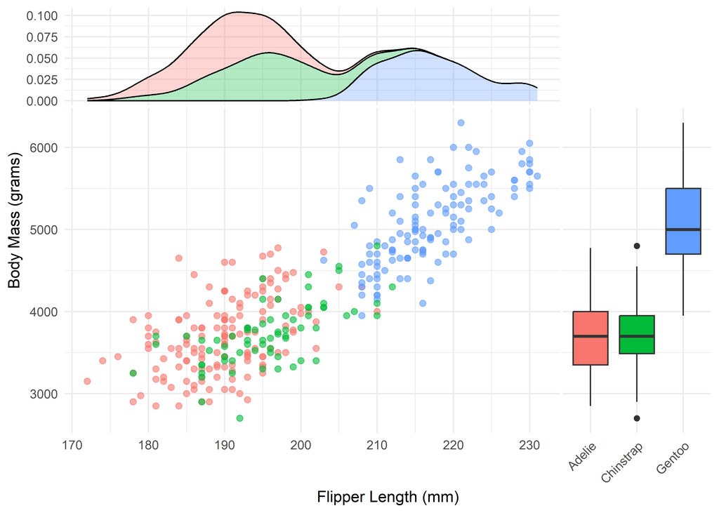

```r
# Load the palmerpenguins and ggside packages
#install.packages("palmerpenguins")
library(ggside)
library(palmerpenguins)

# Extract the penguins data from palmerpenguins
penguins <- penguins

# Create the main plot
main_plot <- ggplot(data = penguins, aes(x = flipper_length_mm, y = body_mass_g)) +
  theme_minimal() +
  geom_point(aes(color = species), alpha = 0.6, size = 1.8)

# Patch the plots together
main_plot + geom_xsidedensity(aes(fill = species), # Create density plot on top
                              alpha = 0.3,
                              position = "stack") + # Each color stacked on top of each other
  # Change scale of top panel
  theme(ggside.panel.scale.x = 0.3) +
  # Create histogram to the right
  geom_ysideboxplot(aes(x = species, fill = species),
                    orientation = "x", # Change orientation from horizontal to vertical
                    show.legend = FALSE) +
  # Change scale of right panel
  theme(ggside.panel.scale.y = 0.3) +
  # Adjust text labels
  labs(x = "Flipper Length (mm)", y = "Body Mass (grams)") +
  scale_ysidex_discrete(guide = guide_axis(angle = 45)) +
  theme(legend.position = "none")
```